# Qunatum Kernel Method

KFUPM - ICS 561 (Project)

# The Journey

- Dataset
- Data Processing & Normlization
- Data Encoding
- Quantum Kernel Estimation
- Result

# Dataset

- The data will be a small subset of the well known handwritten [digits dataset](https://scikit-learn.org/stable/datasets/toy_dataset.html#digits-dataset) (available through scikit-learn).
- The task is to differentiate between `'0'` and `'1'`.

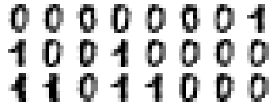

```python
digits = datasets.load_digits(n_class=2)
draw_digit_images(digits)
```

# Data Processing & Normalization

- Simplify the complexity in high-dimensional data while retaining trends and patterns. `Principal Component Analysis (PCA)`.
- Standardize the data values into a standard format.
- Apply `minmax` scale to be between `-1` to `1`.

```python
sample_train, sample_test, label_train, label_test = train_test_split(
     digits.data, digits.target, test_size=0.2, random_state=22)

n_dim = 4
pca = PCA(n_components=n_dim).fit(sample_train)
sample_train = pca.transform(sample_train)
sample_test = pca.transform(sample_test)

std_scale = StandardScaler().fit(sample_train)
sample_train = std_scale.transform(sample_train)
sample_test = std_scale.transform(sample_test)

samples = np.append(sample_train, sample_test, axis=0)
minmax_scale = MinMaxScaler((-1, 1)).fit(samples)
sample_train = minmax_scale.transform(sample_train)
sample_test = minmax_scale.transform(sample_test)
```

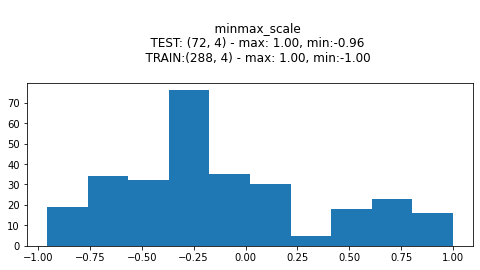

```python
draw_dataset_histogram('minmax_scale', sample_test, sample_train)
```

# Data Encoding

- Implement a `feature map` similar to the one defined below: $$\mathcal{U}_{\Phi(\mathbf{x})} = \left( \exp\left(i\sum_{jk} \phi_{\{j,k\}}(\mathbf{x}) \, Z_j \otimes Z_k\right) \, \exp\left(i\sum_{j} \phi_{\{j\}}(\mathbf{x}) \, Y_j\right) \, \exp\left(i\sum_j \phi_{\{j\}}(\mathbf{x}) \, X_j\right) \, H^{\otimes n} \right)^d.$$

  *Havlicek et al. Nature 567, 209-212 (2019)*

```python
qubits = 4
repeats = 2

x = ParameterVector('x', length=qubits)
var_custom = QuantumCircuit(qubits)

for _ in range(repeats):
    for i in range(qubits):
        var_custom.rx(x[i], i)
    for i in range(qubits):
        for j in range(i + 1, qubits):
            var_custom.cx(i, j)
            var_custom.p(x[i] * x[j], j)
            var_custom.cx(i, j)
    var_custom.barrier()
```

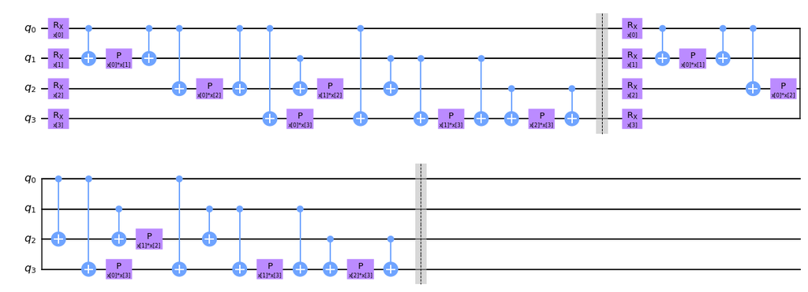

```python
var_custom.draw('mpl')
```

# Quantum Kernel Estimation

Quantum kernel estimation is a technique used in quantum machine learning to estimate the kernel function, which measures the similarity between pairs of data points, using a quantum algorithm

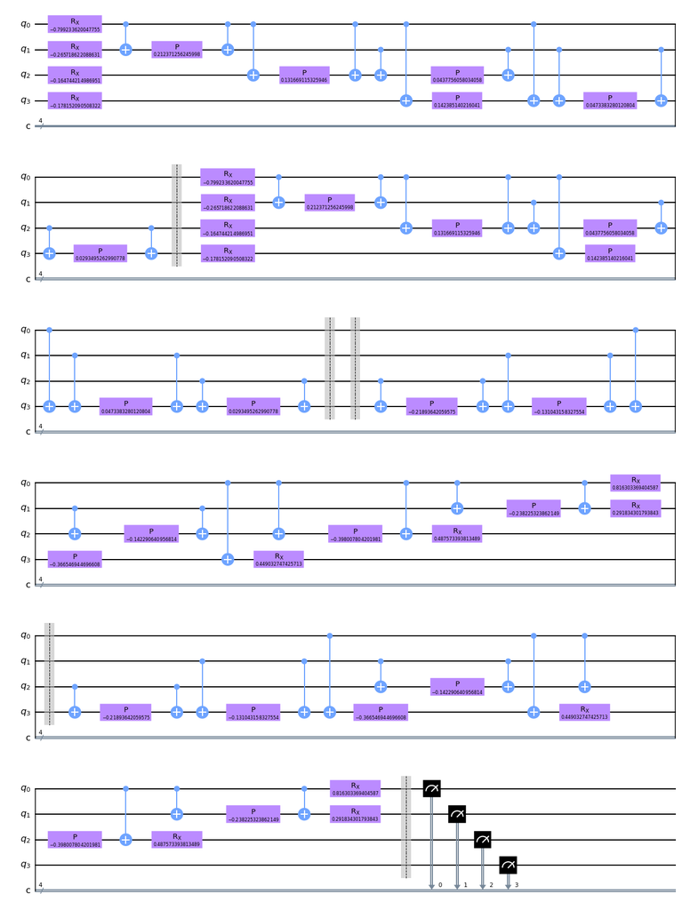

```python
zz_kernel = QuantumKernel(feature_map=var_custom, quantum_instance=Aer.get_backend('statevector_simulator'))

zz_circuit = zz_kernel.construct_circuit(sample_train[0], sample_train[1])
zz_circuit.decompose().draw(output='mpl')
```

# Result

- Kernel Matrices
- SVC by Quantum Kernel
- #SVC by Classical Kernels

## Kernel Matrices

A quantum kernel matrix is a matrix that is used to represent the similarity between pairs of data points in a dataset in the context of quantum machine learning.

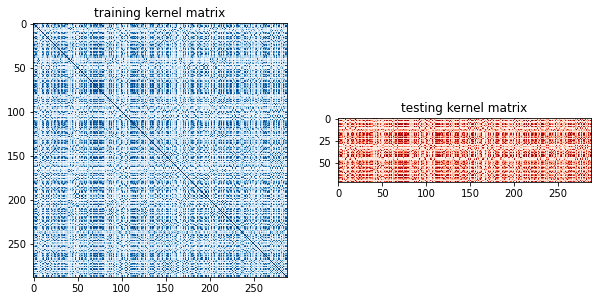

```python
matrix_train = zz_kernel.evaluate(x_vec=sample_train)
matrix_test = zz_kernel.evaluate(x_vec=sample_test, y_vec=sample_train)

draw_matrixes(matrix_train, matrix_test)
```

## SVC by Quantum Kernel

[figure not shown]

```python
zzcb_svc = SVC(kernel=zz_kernel.evaluate)
zzcb_svc.fit(sample_train, label_train)

SVC_QKM_prediction(zzcb_svc, sample_train, label_train, sample_test, label_test)
```

## SVC by Classical Kernels

[figure not shown]

```python
classical_kernels = ['linear', 'poly', 'rbf', 'sigmoid']
SVC_CKM_prediction(classical_kernels)
```